# United States Historical Weather Events and their Impacts

## Synopsis

This analysis is aiming to understand the actual impact of historical weather events in United States, between 1950 and November of 2011. Therefore, we will use the U.S. National Oceanic and Atmospheric Administration“s (NOAA) storm database. The analysis basically measure the impact in human health (considering injuries and fatalities) by type of weather event. Additionally, the analysis measures the economic impact of these weather events, considering damage in properties and crops during the years. At the end of the analysis, we can understand that tornado is the most harmful weather event in the U.S with respect to population health, but floods have the greatest economic consequences in the U.S..

##Data Processing

1. Download and read the data

```r
if (!file.exists('StormData.csv.bz2')) {
   url <- 'https://d396qusza40orc.cloudfront.net/repdata%2Fdata%2FStormData.csv.bz2'
   download.file(url, destfile = 'StormData.csv.bz2', method = 'curl')
}
data <- read.csv('StormData.csv.bz2', stringsAsFactors = FALSE)
```

2. Load needed packages

```r
library(dplyr)
```

```r
library(ggplot2)
library(tidyr)
library(knitr)
```

## Data Analysis

1. Across the United States, which types of events (as indicated in the EVTYPE variable) are most harmful with respect to population health?

To answer this question we will first consider fatalities (FATALITIES in data set) and injuries (INJURIES in data set) as indicators of damage to population health.

```r
casualities.by.type <- data %>%
    # Grouping by event type
    group_by(EVTYPE) %>%
    # Calculating summaries for fatalities and injuries
    summarise(FATALITIES = sum(FATALITIES),
              INJURIES = sum(INJURIES)) %>%
    # Sorting by sum of fatalities and injuries in descending order
    arrange(desc(FATALITIES + INJURIES)) %>%
    # Taking only first 10 records
    slice(1:10) %>%
    # Melting injuries and fatalities
    gather(CType, Value, c(FATALITIES, INJURIES))
```

Now, we can create a graph to see which event has the most impact on population health.

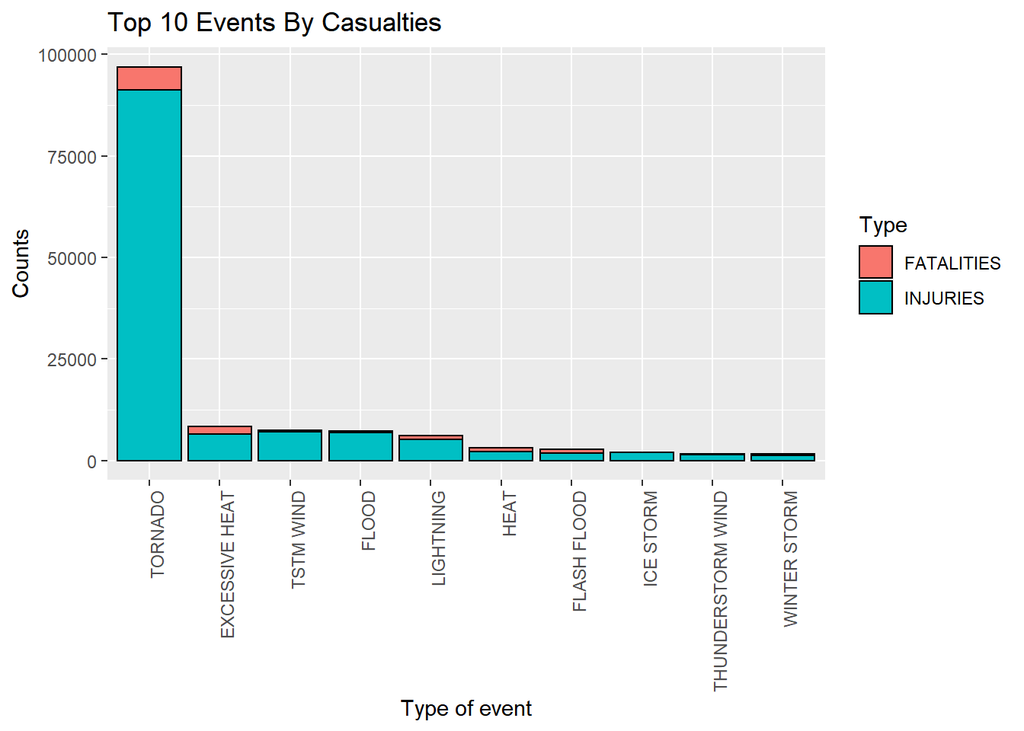

```r
ggplot <- ggplot(data = casualities.by.type,
                 aes(x = reorder(EVTYPE, -Value),
                     y = Value,
                     fill = (CType))) +
    geom_bar(stat = 'identity', col = 'black') +
    labs(title = 'Top 10 Events By Casualties',
         x = 'Type of event',
         y = 'Counts',
         fill = 'Type') +
    theme(axis.text.x = element_text(angle = 90, hjust = 1))

print(ggplot)
```

We can see from the graph that tornadoes have the most impact on population health.

2. Across the United States, which types of events have the greatest economic consequences?

We consider economic consequences as property damage (PROPDMG in database) and crops damage (CROPDMG in database).

first we clean the unnecessary columns.

```r
dt2 <- data[c("EVTYPE", "CROPDMG", "CROPDMGEXP", "PROPDMG", "PROPDMGEXP")]
```

The database doesn’t contain proper values of economic damage, but pairs of a value (RPOPDMG, CROPDMG) and it’s exponent (PROPDMGEXP, CROPDMGEXP). We need to transform them to simple numeric values. We use numeric exponents as they are. For alphabetic characters in exponents we use rules: ‘b’ and ‘B’ stand for billion, ‘m’ and ‘M’ for million, ‘k’ and ‘K’ for thousand, ‘h’ and ‘H’ for hundred (page 12 of Storm Data Documentation). Also we calculate values in millions for convenience.

```r
pd <- dt2$PROPDMG
pde <- dt2$PROPDMGEXP
cd <- dt2$CROPDMG
cde <- dt2$CROPDMGEXP
pde.n <- as.numeric(pde)
pd <- pd * 10 ** replace(pde.n, is.na(pde.n), 0)
pd[pde %in% "B"] <- pd[pde %in% "B"] * 1e9
pd[pde %in% c("M", "m")] <- pd[pde %in% c("M", "m")] * 1e6
pd[pde %in% c("K")] <- pd[pde %in% c("K")] * 1e3
pd[pde %in% c("H", "h")] <- pd[pde %in% c("H", "h")] * 1e2
pd[!(pde %in% c("B", "M", "m", "K", "H", "h"))] <- pd[!(pde %in% c("B", "M",
                                                                   "m", "K", "H", "h"))] * 1
cde.n <- as.numeric(cde)
cd <- cd * 10 ** replace(cde.n, is.na(cde.n), 0)
cd[cde %in% "B"] <- cd[cde %in% "B"] * 1e9
cd[cde %in% c("M", "m")] <- cd[cde %in% c("M", "m")] * 1e6
cd[cde %in% c("K", "k")] <- cd[cde %in% c("K", "k")] * 1e3
cd[!(cde %in% c("B", "M", "m", "K", "k"))] <- cd[!(cde %in% c("B", "M", "m",
                                                              "K", "k"))] * 1
dt2$PROPDMG <- pd
dt2$CROPDMG <- cd
```

Aggregate data by event type

```r
dt2 <- dt2 %>%
    # Droping the columns with exponents
    select(-c(CROPDMGEXP, PROPDMGEXP)) %>%
    # Grouping by event type
    group_by(EVTYPE) %>%
    # Aggregating by property damage and crops damage
    # also shifting to millions
    summarise(PROPDMG = sum(PROPDMG) / 1e6,
              CROPDMG = sum(CROPDMG) / 1e6) %>%
    # Sorting by sum of property damage and crops damage in descending order
    arrange(desc(PROPDMG + CROPDMG)) %>%
    # Taking first 10 records
    slice(1:10) %>%
    # Melting crops/property damage by type for plotting
    gather(TYPE, VALUE, CROPDMG:PROPDMG)
```

Now, we can create a graph to see which event has the highest impact on economy.

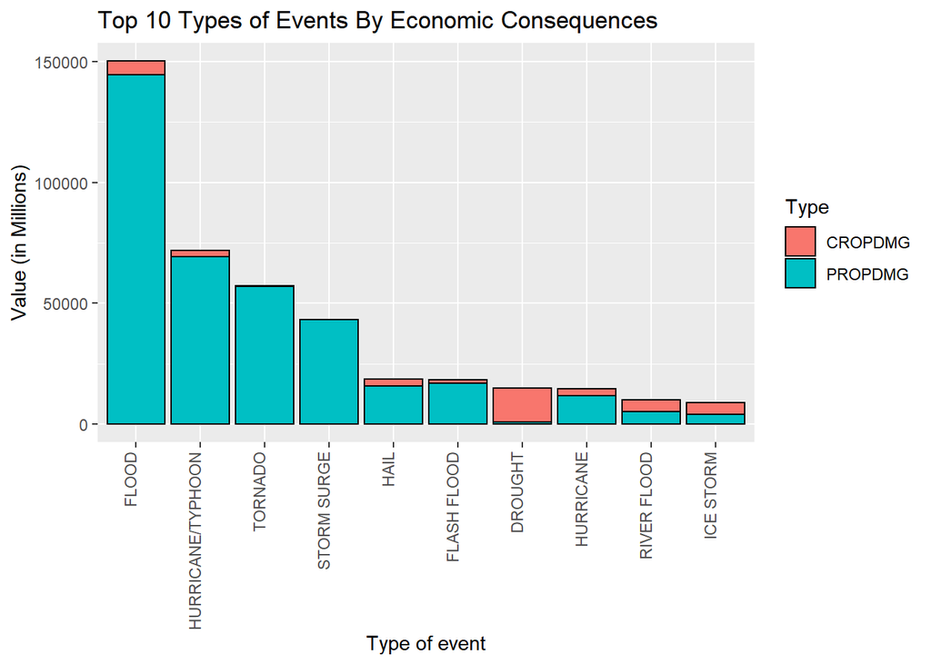

```r
ggp <- ggplot(dt2,
              aes(x = reorder(EVTYPE, -VALUE),
                  y = VALUE, fill = TYPE)) +
    geom_bar(stat = "identity", col = 'black') +
    labs(x = "Type of event", y = "Value (in Millions)") +
    labs(title = "Top 10 Types of Events By Economic Consequences") +
    labs(fill = "Type") +
    theme(axis.text.x = element_text(angle = 90, hjust = 1, vjust = 0))

print(ggp)
```

We can see from the that floods have greatest economic consequences.

## Results

1. Tornado seems to be the most harmful weather event in the U.S with respect to population health.
2. Floods have the biggest economic impact in the U.S.